# TIM - Examen Pratique 2019-2020

## Lundi 13 Janvier 2020

```python
# A compléter
# Importer ici les packages qui vous seront nécessaires pour cette partie de l'examen
import cv2
import numpy as np
from matplotlib import pyplot as plt
```

# Partie Analyse : Restauration d'une vielle Photo

L'objectif de cette partie est de restaurer la vielle photo en dessous (bar.png). Cette photo représente un manque de contraste on utilisera les outils vus en cours permettant de palier ce problème. On pourra également utiliser des outils permettant de "nettoyer" l'image.

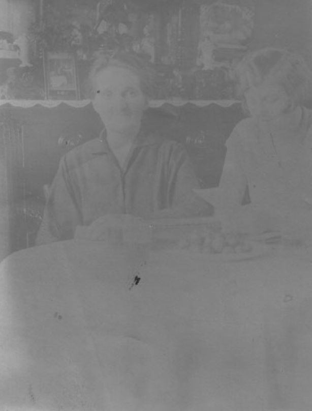

Pour cette partie, nous attendons une démarche scientifique argumentée. Même si vos résultats obtenus ne sont pas à la hauteur de vos attentes, nous voulons une analyse complète de chaque méthode utilisée et de son application dans notre cas. Ne vous contentez pas d'une seule proposition. Si vous ne trouvez pas du premier coup, c'est normal, ça s'appelle la recherche :D

**1)** Quel est le défaut principal de cette image ? Trouvez-vous d'autres défauts notables ? Si oui, lesquels ?

**Réponse :** Je note deux défauts principaux :

- Tout d'abord, on a un gros défaut bien visible, qui est tout simplement le manque de contraste, assez flagrant. L'image est majoritairement grise, et on peut voir que la quasi totalité des pixels se situent entre les valeurs 100 et 175, visible sur l'histogramme suivant.
- Malgré ce manque de contraste, on a 2 ou 3 taches noires assez visibles (valeurs aux alentours de 40).

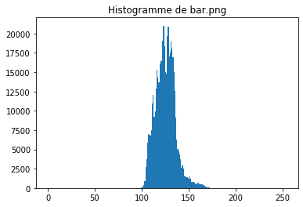

[figure not shown]

```python
img = cv2.imread('../Base_images_exam/bar.png',0)
plt.hist(img.ravel(),bins=range(0,255))
plt.title("Histogramme de bar.png")
plt.show()
plt.hist(img.ravel(),bins=range(40,100))
plt.title("Histogramme de bar.png entre 40 et 100")
plt.show()
```

**2)** Proposez un ou plusieurs outils pour restaurer cette image en justifiant vos choix

**Réponse :** Pour corriger cette image, je vais rectifier les valeurs en dessous de 100 en les plaçant à 100. Cette méthode n'est pas optimale, mais elle permettra d'atténuer fortement les tâches noires. Un lissage aurait pu être possible via un filtre moyenneur, médian ou gaussien par exemple, mais pour pouvoir bien atténuer mes tâches, j'aurais du utiliser un gros kernel et donc fortement modifier le reste de l'image. Une fermeture en morphologie mathématique aurait également pu être envisagée, mais on aurait obtenu le même soucis qu'avec le lissage, pour la même cause (l'utilisation d'un gros kernel).

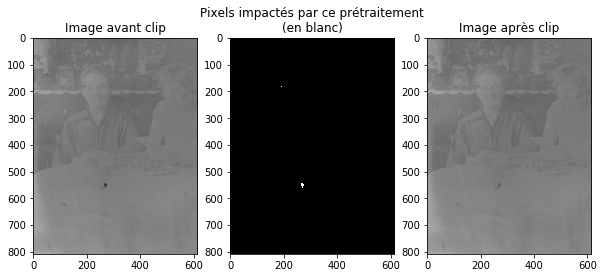

```python
# A compléter
# Atténuation des taches noires
img_clipped = np.clip(img,100,175)
plt.subplots(1,3,figsize=(10,10))
plt.subplot(131)
plt.imshow(img,'gray',vmin=0,vmax=255)
plt.title('Image avant clip')
plt.subplot(132)
plt.imshow(cv2.threshold(img,99,255,cv2.THRESH_BINARY_INV)[1],'gray')
plt.title('Pixels impactés par ce prétraitement\n(en blanc)')
plt.subplot(133)
plt.imshow(img_clipped,'gray',vmin=0,vmax=255)
plt.title('Image après clip')
plt.show()
```

Ensuite, je vais appliquer une égalisation d'histogramme afin d'augmenter le contraste de l'image.

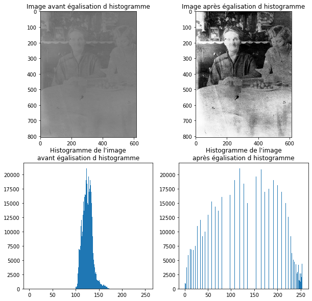

```python
# Egalisation d'histogramme
img_equal = cv2.equalizeHist(img_clipped)
plt.subplots(2,2,figsize=(10,10))
plt.subplot(221)
plt.imshow(img_clipped,'gray',vmin=0,vmax=255)
plt.title('Image avant égalisation d histogramme')
plt.subplot(222)
plt.imshow(img_equal,'gray',vmin=0,vmax=255)
plt.title('Image après égalisation d histogramme')
plt.subplot(223)
plt.hist(img_clipped.ravel(),bins=range(0,255))
plt.title("Histogramme de l'image\navant égalisation d histogramme")
plt.subplot(224)
plt.hist(img_equal.ravel(),bins=range(0,255))
plt.title("Histogramme de l'image\naprès égalisation d histogramme")
plt.show()
```

On va maintenant analyser l'impact de mon appel de clip pour atténuer les tâches noires, car elles restent assez visibles.

[figure not shown]

```python
# Egalisation d'histogramme
img_equal_wo_clip = cv2.equalizeHist(img_clipped)
plt.subplots(2,2,figsize=(10,10))
plt.subplot(221)
plt.imshow(img_equal_wo_clip,'gray',vmin=0,vmax=255)
plt.title('Image sans clip après égalisation d histogramme')
plt.subplot(222)
plt.imshow(img_equal,'gray',vmin=0,vmax=255)
plt.title('Image avec clip après égalisation d histogramme')
plt.subplot(223)
plt.hist(img_equal_wo_clip.ravel(),bins=range(0,255))
plt.title("Histogramme de l'image sans clip\naprès égalisation d histogramme")
plt.subplot(224)
plt.hist(img_equal.ravel(),bins=range(0,255))
plt.title("Histogramme de l'image avec clip\naprès égalisation d histogramme")
plt.show()
```

**3)** Analysez le(s) résultat(s) obtenu(s). N'oubliez pas de comparer les résultats des différentes méthodes entre eux.

La fonction d'égalisation d'histogramme donne cependant le résultat attendu, à savoir un fort réhaussement de contraste, ce qui est très satisfaisant. Cependant, les tâches noires restent visibles et nous avons une zone en bas à gauche très fortement lumineuse, qui serait intéressant d'atténuer.

**4)** Selon le résultat, vos choix étaient-ils adaptés au problème ? Pourquoi ?

## Rendu

Le rendu qui vous est demandé est la version HTML de ce notebook. Pour l'obtenir: Fichier, télécharger au format, HTML (.html). Vous le déposerez en fin d'examen sur Moodle, dans un dépot prévu à cet effet, dans le format NOM_Prenom_P2.html.